# SC-ION Version 3.0

Natalie M. Clark[^1]

2022-04-06

# Summary

Known compatibility: R 3.6.3, R 4.1.3

Version 3.0 of SC-ION adds the following functionality:

- Packages are now automatically installed and loaded using the pacman package.
- Cluster expression is no longer automatically plotted, and the “Cluster Plots” folder is no longer automatically generated. This is to reduce the runtime of the clustering methods. Cluster expression plots can still be generated by uncommenting the plotting code in the ica_clustering.R (non-temporal) and/or dtw_clustering.R (temporal) files.
- The help text present in the RShiny App Window is now also included as a .html vignette file.
- Fixes multiple issues with network inference including adding checks for enough regulators/targets when using clustering and dealing with PTM information in regulator names. We recommend users denote PTM sites in regulator names using a “.” (e.g. SOX2.S35) as this is a character not usually present in gene symbols, making it easy to separate the PTM site from the gene name if desired in downstream processing.
- Networks are no longer trimmed automatically. Rather, the user chooses an edge weight cutoff to use for trimming. For more details, see the vignette.
- Changes definition of the clustering threshold for non-temporal clustering. For more details, see the vignette.
- Using the arrows on the edge weight or clustering thresholds will increment by 0.1. NOTE: There is a known issue on MacOS where the arrows will increment by twice the desired step size (e.g. 0.2 instead of 0.1). The user can always specify an exact number by typing it into the box.
- Adds a button which will save a screenshot of the window to the working directory.

# How to run SC-ION

Download all R files to your computer from Github. The files will be downloaded in a .zip folder. Extract the .zip folder. This is your directory which contains SC-ION. Make sure to change the working directory in the “START_SCION.R” file to the directory which contains all of the R code that you downloaded from Github. Then, run the START_SCION.R file to build the RShiny App. Follow the instructions in the RShiny App (or in this vignette) to run your data.

# Known Issues

- This method will automatically write over files with the same name in your working directory. If you would like to compare your results, make sure to move them from your working directory or change your directory to prevent them being written over.
- If you have previously used packages that load rlang (such as tidyverse), you may receive an error when trying to install some packages (such as dtwclust) that you need to update rlang, but it cannot be done. To fix this, you need to delete the rlang folder from your R folder, and then reinstall.
- Version 3.0 has only been tested on R versions 3.6.3 and 4.1.3. It may not work on other versions of R.

# Input Files

NOTE: Currently SCION only takes comma separated values (.csv) files as input.

## Working Directory

Name of your working directory which MUST contain all of your files (e.g. target matrix, target list, etc). This can be a different directory than the directory containing the SC-ION code.

## Target Matrix

Data matrix to use for your targets (e.g. transcript data). Columns are samples, rows are features (e.g. genes). The target matrix can contain as many features as you wish (e.g. all detected genes in an RNASeq experiment). The Target List is used to extract your genes of interest from the target matrix.

## Regulator Matrix

Data matrix to use for your regulators (e.g. protein data). Columns are samples, rows are features (e.g. protein groups). If your regulators contain additional information such as a PTM site, this should be denoted using a “.” (e.g. SOX2.S35). The regulator matrix can contain as many features as you wish (e.g. all detected protein groups in a proteome experiment). The Regulator List is used to extract your features of interest from the regulator matrix.

## Target List

List of features you consider targets in your network. The target list is used to extract specific rows from the target matrix, so make sure to use the same formatting for gene symbols, etc.

## Regulator List

List of features you consider regulators in your network (e.g. transcription factors). If your regulators contain additional information such as a PTM site, this should be denoted using a “.” (e.g. SOX2.S35). The regulator list is used to extract specific rows from the regulator matrix, so make sure to use the same formatting for gene symbols, PTMs, etc.

## Edge Weight Cutoff

Cutoff to use for trimming the network. A cutoff of 0 keeps all inferred edges. The closer the cutoff is to 1, the less edges are kept. Higher cutoff = more confidence in the inferred edges. We recommend using some sort of cutoff except in the case of very small networks. Default: 0.33

## Clustering

Select if you are clustering using Temporal or Non-Temporal data. Select Upload to use your own file. Select None if you do not wish to cluster (only recommended for small networks).

## Clustering Matrix

Data matrix to use to cluster your gene targets. Columns are samples, rows are features (e.g. genes, protein groups). This is only required if you choose to cluster using Temporal or Non-Temporal data.

## Clustering Threshold

Indicate the clustering threshold to use. The clustering threshold is how similar the features must be to be clustered together. The threshold works differently depending on the clustering method selected. Default: 0.5.

For Temporal Clustering: Range 0 to 1. If you pick a threshold close to 1, you will obtain many clusters with high within-cluster similarity. If you pick a threshold close to 0, you will obtain few clusters with low within-cluster similarity.

For Non-Temporal Clustering: Range 0 to 5. If you pick a threshold close to 5, you will obtain few clusters with low within-cluster similarity. If you pick a threshold close to 0, you will obtain many clusters with high within-cluster similarity.

## Clusters File

If uploading your own file with pre-determined clusters, select it here. The first column must be the names of your features, and there must be a column called “clusters” that contains each cluster number. For an example of how this file should be formatted, see the “clusters.csv” file included in the test data. This is only required if you choose Upload as your clustering method. If using any of the other Clustering options, leave this field blank.

If you infer a network using SC-ION, and you would like to re-infer the network, you can use the generated “clusters.csv” file as input to preserve the previous clustering configuration and also reduce any computational time due to the clustering step.

## Hub Connection

Choose Yes if you want to connect the clusters using their hubs (recommended). Choose No if you do not want to use hub connection. This option is not used if you are not clustering.

# Output Files

All of the following output files are saved to your working directory:

-If you cluster, a file named “clusters.csv” which contains your clustering results. -If you cluster, a folder is created named “Cluster networks” which will contain individual networks for each of your clusters. These networks are combined to form the final network. -A text file named “FINAL_NETWORK.txt” which contains the final network. This can be imported into visualization softwares such as Cytoscape.

# Test data

Test data are provided in the TEST.zip folder. Download and unzip the files, then run using the following settings:

- Working directory: wherever your test files are (you can copy and paste the path from Windows/Mac file explorer)
- Target matrix: target_mat_test.csv
- Regulator matrix: reg_mat_test.csv
- Target list: target_list_test.csv
- Regulator list: reg_list_test.csv
- Edge threshold: leave at the default value of 0.33
- Clustering: You can use either Temporal or Non-Temporal and compare the results.
- Clustering matrix: cluster_test.csv
- Clustering threshold: If using temporal clustering, use 0.5. If using non-temporal clustering, use 2.
- Clusters file: Leave empty
- Hub connection: No

You can check your settings using the image below. These are the settings for non-temporal clustering.

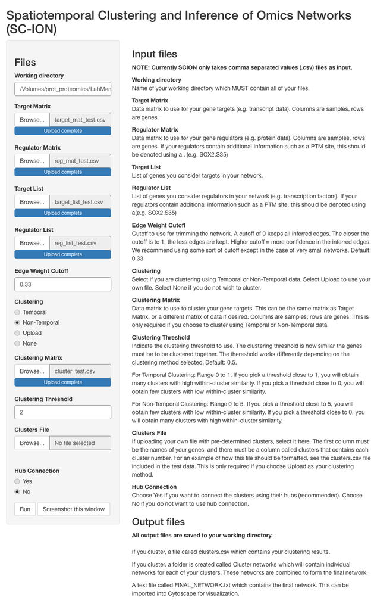

# Other questions?

Please contact Natalie Clark via email (see the footnote) and/or report an issue on Github.

[^1]: nclark@broadinsitute.org